# Tutorial for the landpred package

Dylan Huynh and Layla Parast

If you are viewing the html version of this tutorial, you can find the R markdown file here: https://github.com/laylaparast/landpred. It is the file called landpred_tutorial.Rmd. In this tutorial we will go through examples using the main functions in the **landpred** R package which can be installed from Github or CRAN. First, install and load the package.

```r
library(devtools)
# devtools::install_github('laylaparast/landpred')
library(landpred)
```

## Introduction

This landpred package provides nonparametric methods for landmark prediction of long-term survival outcomes, incorporating covariate and short-term event information. The goal is to improve prediction accuracy when a censored short-term event is available as a predictor, using robust nonparametric procedures that avoid restrictive parametric assumptions found in alternative methods. More information on these methods can be found in Parast et al. (2012, Journal of the American Statistical Association, https://doi.org/10.1080/01621459.2012.721281), and Parast et al. (2011, Biometrical Journal, https://doi.org/10.1002/bimj.201000150), and Parast and Cai (2013, Statistics in Medicine, http://doi.org/10.1002/sim.5776).

Earlier versions of this package (1.0, 1.1, 1.2) did not include the varying coefficient method. Version 2.0, covered in this tutorial, was developed by [Dylan Huynh](https://baolong281.github.io/) and does include the varying coefficient method and other major improvements in package implementation.

## Generating Data

We will generate a dataframe with two continuous covariates, $Z_1,Z_2$, and one discrete covariate, $B$. We will also have a censored short-term event $X_S$ and a censored long-term event, our primary outcome, $X_L$. While there is also an example dataset in the package, it does not have a continuous covariate, hence our generation of this dataset.

```r
set.seed(1)
n = 500
# Generate covariates
Z1 = rnorm(n)
Z2 = rnorm(n)
B = rbinom(n, 1, 0.5)  # Binary discrete covariate

# Generate event times
X_L_raw = exp(0.5 * Z1 + 0.4 * Z2 + 0.5 * B) + rexp(n,1)
X_S_raw = exp(0.1 * Z1 + 0.2 * Z2 + 0.1 * B) + rexp(n,1)

# Generate censoring times
C_L = runif(n, 0.2, 10)  # censoring for long-term event
C_S = runif(n, 0.1, 5)  # censoring for short-term event

# Apply censoring
X_L = pmin(X_L_raw, C_L)
D_L = as.numeric(X_L_raw <= C_L)  # 1 if event, 0 if censored

X_S = pmin(X_S_raw, C_S)
D_S = as.numeric(X_S_raw <= C_S)  # 1 if event, 0 if censored

# Return simple data frame
df = data.frame(
  X_L = X_L,       # long-term event time
  D_L = D_L,       # long-term event indicator
  X_S = X_S,       # short-term event time
  D_S = D_S,       # short-term event indicator
  Z1 = Z1,         # continuous covariate 1
  Z2 = Z2,         # continuous covariate 2
  B = B            # discrete covariate
)
```

Let’s take a look at the Kaplan-Meier survival curves for the long-term outcome, the long-term outcome stratified by the discrete covariate, and the short-term outcome.

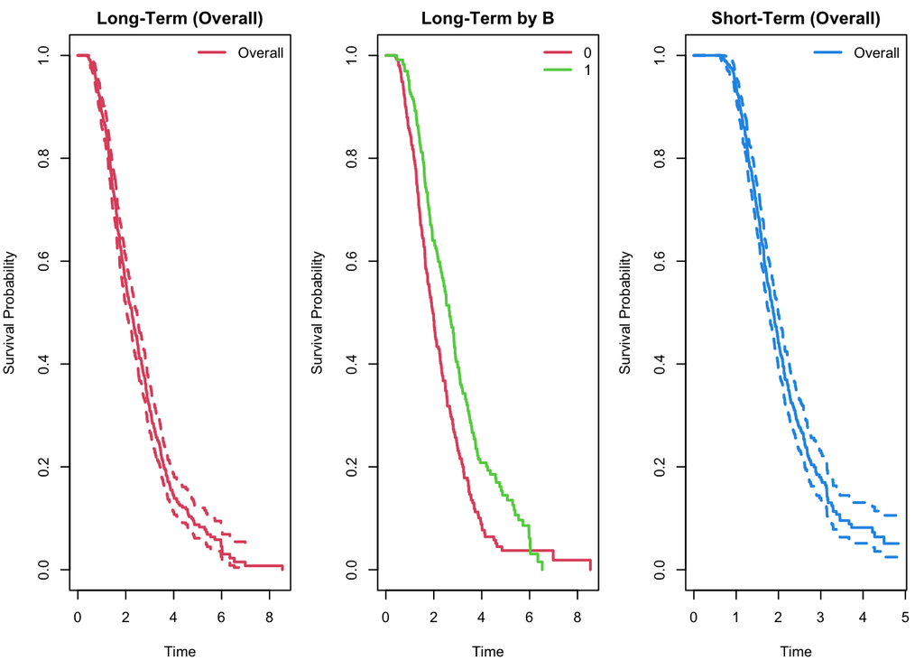

```r
library(survival)
par(mfrow = c(1, 3), mar = c(4, 4, 2, 1))

# --- 1: Long-term, no covariates ---
fit_L = survfit(Surv(X_L, D_L) ~ 1, data = df)
plot(fit_L, col = 2, lwd = 2, xlab = "Time", ylab = "Survival Probability",
    main = "Long-Term (Overall)")
legend("topright", legend = "Overall", col = 2, lwd = 2, bty = "n")

# --- 2: Long-term, by discrete B ---
fit_L_B = survfit(Surv(X_L, D_L) ~ B, data = df)
plot(fit_L_B, col = 2:6, lwd = 2, xlab = "Time", ylab = "Survival Probability",
    main = "Long-Term by B")
legend("topright", legend = levels(factor(df$B)), col = 2:6,
    lwd = 2, bty = "n")

# --- 3: Short-term, no covariates ---
fit_S = survfit(Surv(X_S, D_S) ~ 1, data = df)
plot(fit_S, col = 4, lwd = 2, xlab = "Time", ylab = "Survival Probability",
    main = "Short-Term (Overall)")
legend("topright", legend = "Overall", col = 4, lwd = 2, bty = "n")
```

## General Workflow

The package exports the `landpred` function, which will construct a landpred object given a formula and data. We can supply short-term event information, and continuous or discrete covariates, as demonstrated below. Note that short-term event information needs to be wrapped in a `Surv` from the `survival` package. We can call `summary` on this landpred object to get more information from it. Let’s walk through some examples.

## Model Examples

Let’s start with a naive prediction model where we use no short-term event or covariate information for prediction. Throughout, we are focused on predicting the probability that `TL<t0+tau` given `TL>t0`. We first set our `t0` and `tau` and then build a prediction model that uses no covariates as shown below.

```r
t0 = 2
tau = 1

# model with no information
model1 = get_model(landpred(Surv(X_L, D_L) ~ 1, data = df, discrete = TRUE,
    no.covariates = TRUE), t0 = t0, tau = tau)
model1
```

```
##
## Discrete Landpred Model (No Discrete covariate + no short-term event):
##
## Call:
## landpred(formula = Surv(X_L, D_L) ~ 1)
##
## Probs:
## P(TL < t0 + tau): 0.443
##
## t0: 2.000      tau: 1.000
```

This model is naive in the sense that since it is given no information, it simply uses the overall estimate from the sample. We can obtain predictions and estimate the training Area under the ROC curve (AUC). As expected, the (training) AUC is 0.5.

```r
# obtain predictions
probs1 = predict(model1, newdata = df)

# AUC function needs data in this form
pred_data = cbind(df[, c("X_L", "D_L")], probs1)

# calculate AUC
AUC.landmark(t0 = t0, tau = tau, data = pred_data)
```

```
## $AUC.est
## [1] 0.5
```

Now let’s consider only including a single discrete covariate, examine the model and training AUC.

```r
# model with only discrete covariate
model2 = get_model(landpred(Surv(X_L, D_L) ~ B, data = df, discrete = TRUE),
    t0 = t0, tau = tau)
model2
```

```
##
## Discrete Landpred Model (Discrete covariate + no short-term event):
##
## Call:
## landpred(formula = Surv(X_L, D_L) ~ B)
##
## Probs:
## P(TL < t0+tau|Z=1): 0.386
## P(TL < t0+tau|Z=0): 0.512
##
## t0: 2.000      tau: 1.000
```

```r
# predictions
probs2 = predict(model2, newdata = df)
pred_data = cbind(df[, c("X_L", "D_L")], probs2)

# AUC
AUC.landmark(t0 = t0, tau = tau, data = pred_data)
```

```
## $AUC.est
## [1] 0.5632239
```

And now let’s consider the discrete covariate and the short-term event information.

```r
model3 = get_model(landpred(Surv(X_L, D_L) ~ Surv(X_S, D_S) +
    B, data = df, discrete = TRUE), t0 = t0, tau = tau)
probs3 = predict(model3, newdata = df)
pred_data = cbind(df[, c("X_L", "D_L")], probs3)

# AUC
AUC.landmark(t0 = t0, tau = tau, data = pred_data)
```

```
## $AUC.est
## [1] 0.6028785
```

Next, let’s consider both continuous covariates and the short-term event information. In addition, we showcase our function to optimize the bandwidth using cross-validation.

```r
# create model
obj1 = landpred(Surv(X_L, D_L) ~ Surv(X_S, D_S) + Z1 + Z2, data = df)

# find bandwidth
bw = optimize_bandwidth(obj1, t0 = t0, tau = tau, lower = 0.01,
    upper = 1)

bw
```

```
## [1] 0.3881464
```

```r
# Get model using the optimized bandwidth
model = get_model(obj1, t0 = t0, tau = tau, bw = bw, transform = identity)

model
```

```
##
## Continuous Landpred Model:
## Call coef() or summary() with t_s to see coefficients.
##
## Call:
## landpred(formula = Surv(X_L, D_L) ~ Surv(X_S, D_S) + Z1 + Z2)
##
## t0: 2.000      tau: 1.000
```

With one or more continuous covariates, the model becomes more complicated and involves a varying coefficient model. The coefficients for each covariate vary as a function of the short-term event. First, we can look at the coefficients for each covariate when a short-term event has not occurred by time `t0` as follows.

```r
summary(model)
```

```
##
## Continuous Landpred Model:
##
## Coefficients (No short-term event):
```

```
##             Estimate Std. Error
## (Intercept)  0.17322     0.1674
## Z1          -0.72924     0.1728
## Z2          -0.63371     0.1588
## ---
## Fit on n=213 observations.
##
## t0: 2.000      tau: 1.000
```

To view the covariate coefficients for a specific time of the short-term event, for example at 0.3, we can use the summary function as follows:

```r
summary(model, t_s = 0.3)
```

```
##
## Continuous Landpred Model:
##
## Coefficients (t_s=0.300000):
##             Estimate Std. Error
## (Intercept) -0.18243     0.5419
## Z1           0.32634     0.6320
## Z2          -0.28472     0.9302
## ---
## Fit on n=79 observations.
##
## t0: 2.000      tau: 1.000
```

These estimates are the locally-weighted coefficients from the varying coefficient model.

## Prediction

Let’s take a closer look at the predictions from this model. Note that if a person does not survive past the t0 time, their landmark prediction is undefined and is shown as NA.

```r
# first 10 observations
df[1:10, , drop = FALSE]
```

```
##          X_L D_L       X_S D_S         Z1          Z2 B
## 1  1.2952451   1 2.2770255   1 -0.6264538  0.07730312 1
## 2  3.8577288   1 1.4646701   1  0.1836433 -0.29686864 1
## 3  0.9695464   1 0.4461303   0 -0.8356286 -1.18324224 1
## 4  2.9363222   1 0.1067216   0  1.5952808  0.01129269 0
## 5  0.7511612   0 1.9225657   1  0.3295078  0.99160104 0
## 6  2.4856479   1 2.4206734   1 -0.8204684  1.59396745 0
## 7  2.1377543   1 1.0229057   1  0.4874291 -1.37271127 1
## 8  1.3656538   1 1.2845029   1  0.7383247 -0.24961093 0
## 9  3.5539677   0 1.7060931   1  0.5757814  1.15942453 1
## 10 0.6412071   1 3.7269661   1 -0.3053884 -1.11422235 0
```

```r
# predictions for first 10 observations
probs = predict(model, newdata = df[1:10, , drop = FALSE])
probs
```

```
##  [1]        NA 0.5566139        NA 0.2694768        NA 0.6927119 0.6654479
##  [8]        NA 0.2726147        NA
```

These probabilities represent the estimated probability of the long-term event occurring by time `t0 + tau`, conditional on survival to the landmark time `t0`. Here, newdata is a dataframe also containing the short event information for each observation. If this short event time is less than the value of `t_0`, then the short-term event time is incorporated into the probability, giving `P(X_L < t_0 + tau | Z=z, X_s=t_s)`. If the short-term event time is greater than `t_0`, then the short-term event time is not incorporated into the probability, giving instead `P(X_L < t_0 + tau | Z=z)`.

We can evaluate the prediction accuracy by calculating the Area under the ROC Curve (AUC), as above (or the Brier Score). Let’s properly look at the AUC using a training and a validation set.

```r
n = nrow(df)
set.seed(1)
train_prop = 0.6
n_train = floor(n * train_prop)

# create training and validation sets
ind_train = sample(1:n, n_train)
ind_val = setdiff(1:n, ind_train)
df_train = df[ind_train, ]
df_val = df[ind_val, ]

# fit the model above to only the training data; find
# bandwidth
obj1 = landpred(Surv(X_L, D_L) ~ Surv(X_S, D_S) + Z1 + Z2, data = df_train)
bw = optimize_bandwidth(obj1, t0 = t0, tau = tau, lower = 0.01,
    upper = 1)
model1 = get_model(obj1, t0 = t0, tau = tau, bw = bw)

# get predictions for validation set
probs1 = predict(model1, newdata = df_val)

# calculate AUC
pred_data = cbind(df_val[, c("X_L", "D_L")], probs1)
AUC.landmark(t0 = t0, tau = tau, data = pred_data)
```

```
## $AUC.est
## [1] 0.719783
```

That’s all for now! If you have any questions or need any help, please email: parast@austin.utexas.edu.